# Investigate_A_Dataset

## 1. Introduction

For this project we were asked to select the dataset and using the data we were asked to answer various questions. I will use various python libraries like NumPy,Pandas and Matplotlib to make the analysis.I have taken titanic dataset to perform the analysis. Before starting with the project we all should know about the 'TITANIC' a little.

The sinking of the RMS Titanic is one of the most infamous shipwrecks in history. On April 15, 1912, during her maiden voyage, the Titanic sank after colliding with an iceberg, killing 1502 out of 2224 passengers and crew. This sensational tragedy shocked the international community and led to better safety regulations for ships.

One of the reasons that the shipwreck led to such loss of life was that there were not enough lifeboats for the passengers and crew. Although there was some element of luck involved in surviving the sinking, some groups of people were more likely to survive than others, such as women, children, and the upper-class

### 1.1 Description of the dataset

Here is the short description about the titanic dataset. The dataset of study contains demographics and passenger information from 891 of the 2224 passengers and crew on board the Titanic.

| About | Description |
| --- | --- |
| PassengerId | Id given to each passenger on boat |
| Survived | Survival(0 = No,1 = Yes) |
| Pclass | Passenger class (1 = first; 2 = second; 3 = third) |
| Name | Name |
| Sex | Sex |
| Age | Age |
| SibSp | Number of siblings and spouses traveling with the passenger. |
| Parch | Number of parents and children traveling with the passenger. |
| Ticket | The ticket number. |
| Fare | The ticket Fare |
| Cabin | The cabin number |
| Embarked | Port of embarkation (C = Cherbourg; Q = Queenstown; S = Southampton) |

### 1.2 Questions:

In the analysis we will analyse various questions and answer them.  
Here are some questions that we'll look in the analysis.

- Which gender has the more survival rate?
- How was the age affected the number of survivors?
- Which class people were given more preference?
- How fare was different for men and women?

## 2. Reading CSV

Here we will load the csv file and look at the various results. We will look at the total entries and the missing values.

```python
import numpy as np
import pandas as pd
from pandas import DataFrame
import matplotlib.pyplot as plt
%matplotlib inline
import seaborn as sns
sns.set(style="whitegrid")
plt.style.use('ggplot')
from numbers import Number
from scipy import stats
%pylab inline
```

```python
# reading titanic data
data=pd.read_csv('titanic_data.csv')

# view dataframe
data
```

|  | PassengerId | Survived | Pclass | Name | Sex | Age | SibSp | Parch | Ticket | Fare | Cabin | Embarked |
| --- | --- | --- | --- | --- | --- | --- | --- | --- | --- | --- | --- | --- |
| 0 | 1 | 0 | 3 | Braund, Mr. Owen Harris | male | 22.0 | 1 | 0 | A/5 21171 | 7.2500 | NaN | S |
| 1 | 2 | 1 | 1 | Cumings, Mrs. John Bradley (Florence Briggs Th... | female | 38.0 | 1 | 0 | PC 17599 | 71.2833 | C85 | C |
| 2 | 3 | 1 | 3 | Heikkinen, Miss. Laina | female | 26.0 | 0 | 0 | STON/O2. 3101282 | 7.9250 | NaN | S |
| 3 | 4 | 1 | 1 | Futrelle, Mrs. Jacques Heath (Lily May Peel) | female | 35.0 | 1 | 0 | 113803 | 53.1000 | C123 | S |
| 4 | 5 | 0 | 3 | Allen, Mr. William Henry | male | 35.0 | 0 | 0 | 373450 | 8.0500 | NaN | S |
| 5 | 6 | 0 | 3 | Moran, Mr. James | male | NaN | 0 | 0 | 330877 | 8.4583 | NaN | Q |
| 6 | 7 | 0 | 1 | McCarthy, Mr. Timothy J | male | 54.0 | 0 | 0 | 17463 | 51.8625 | E46 | S |
| 7 | 8 | 0 | 3 | Palsson, Master. Gosta Leonard | male | 2.0 | 3 | 1 | 349909 | 21.0750 | NaN | S |
| 8 | 9 | 1 | 3 | Johnson, Mrs. Oscar W (Elisabeth Vilhelmina Berg) | female | 27.0 | 0 | 2 | 347742 | 11.1333 | NaN | S |
| 9 | 10 | 1 | 2 | Nasser, Mrs. Nicholas (Adele Achem) | female | 14.0 | 1 | 0 | 237736 | 30.0708 | NaN | C |
| 10 | 11 | 1 | 3 | Sandstrom, Miss. Marguerite Rut | female | 4.0 | 1 | 1 | PP 9549 | 16.7000 | G6 | S |
| 11 | 12 | 1 | 1 | Bonnell, Miss. Elizabeth | female | 58.0 | 0 | 0 | 113783 | 26.5500 | C103 | S |
| 12 | 13 | 0 | 3 | Saundercock, Mr. William Henry | male | 20.0 | 0 | 0 | A/5. 2151 | 8.0500 | NaN | S |
| 13 | 14 | 0 | 3 | Andersson, Mr. Anders Johan | male | 39.0 | 1 | 5 | 347082 | 31.2750 | NaN | S |
| 14 | 15 | 0 | 3 | Vestrom, Miss. Hulda Amanda Adolfina | female | 14.0 | 0 | 0 | 350406 | 7.8542 | NaN | S |
| 15 | 16 | 1 | 2 | Hewlett, Mrs. (Mary D Kingcome) | female | 55.0 | 0 | 0 | 248706 | 16.0000 | NaN | S |
| 16 | 17 | 0 | 3 | Rice, Master. Eugene | male | 2.0 | 4 | 1 | 382652 | 29.1250 | NaN | Q |
| 17 | 18 | 1 | 2 | Williams, Mr. Charles Eugene | male | NaN | 0 | 0 | 244373 | 13.0000 | NaN | S |
| 18 | 19 | 0 | 3 | Vander Planke, Mrs. Julius (Emelia Maria Vande... | female | 31.0 | 1 | 0 | 345763 | 18.0000 | NaN | S |
| 19 | 20 | 1 | 3 | Masselmani, Mrs. Fatima | female | NaN | 0 | 0 | 2649 | 7.2250 | NaN | C |
| 20 | 21 | 0 | 2 | Fynney, Mr. Joseph J | male | 35.0 | 0 | 0 | 239865 | 26.0000 | NaN | S |
| 21 | 22 | 1 | 2 | Beesley, Mr. Lawrence | male | 34.0 | 0 | 0 | 248698 | 13.0000 | D56 | S |
| 22 | 23 | 1 | 3 | McGowan, Miss. Anna "Annie" | female | 15.0 | 0 | 0 | 330923 | 8.0292 | NaN | Q |
| 23 | 24 | 1 | 1 | Sloper, Mr. William Thompson | male | 28.0 | 0 | 0 | 113788 | 35.5000 | A6 | S |
| 24 | 25 | 0 | 3 | Palsson, Miss. Torborg Danira | female | 8.0 | 3 | 1 | 349909 | 21.0750 | NaN | S |
| 25 | 26 | 1 | 3 | Asplund, Mrs. Carl Oscar (Selma Augusta Emilia... | female | 38.0 | 1 | 5 | 347077 | 31.3875 | NaN | S |
| 26 | 27 | 0 | 3 | Emir, Mr. Farred Chehab | male | NaN | 0 | 0 | 2631 | 7.2250 | NaN | C |
| 27 | 28 | 0 | 1 | Fortune, Mr. Charles Alexander | male | 19.0 | 3 | 2 | 19950 | 263.0000 | C23 C25 C27 | S |
| 28 | 29 | 1 | 3 | O'Dwyer, Miss. Ellen "Nellie" | female | NaN | 0 | 0 | 330959 | 7.8792 | NaN | Q |
| 29 | 30 | 0 | 3 | Todoroff, Mr. Lalio | male | NaN | 0 | 0 | 349216 | 7.8958 | NaN | S |
| ... | ... | ... | ... | ... | ... | ... | ... | ... | ... | ... | ... | ... |
| 861 | 862 | 0 | 2 | Giles, Mr. Frederick Edward | male | 21.0 | 1 | 0 | 28134 | 11.5000 | NaN | S |
| 862 | 863 | 1 | 1 | Swift, Mrs. Frederick Joel (Margaret Welles Ba... | female | 48.0 | 0 | 0 | 17466 | 25.9292 | D17 | S |
| 863 | 864 | 0 | 3 | Sage, Miss. Dorothy Edith "Dolly" | female | NaN | 8 | 2 | CA. 2343 | 69.5500 | NaN | S |
| 864 | 865 | 0 | 2 | Gill, Mr. John William | male | 24.0 | 0 | 0 | 233866 | 13.0000 | NaN | S |
| 865 | 866 | 1 | 2 | Bystrom, Mrs. (Karolina) | female | 42.0 | 0 | 0 | 236852 | 13.0000 | NaN | S |
| 866 | 867 | 1 | 2 | Duran y More, Miss. Asuncion | female | 27.0 | 1 | 0 | SC/PARIS 2149 | 13.8583 | NaN | C |
| 867 | 868 | 0 | 1 | Roebling, Mr. Washington Augustus II | male | 31.0 | 0 | 0 | PC 17590 | 50.4958 | A24 | S |
| 868 | 869 | 0 | 3 | van Melkebeke, Mr. Philemon | male | NaN | 0 | 0 | 345777 | 9.5000 | NaN | S |
| 869 | 870 | 1 | 3 | Johnson, Master. Harold Theodor | male | 4.0 | 1 | 1 | 347742 | 11.1333 | NaN | S |
| 870 | 871 | 0 | 3 | Balkic, Mr. Cerin | male | 26.0 | 0 | 0 | 349248 | 7.8958 | NaN | S |
| 871 | 872 | 1 | 1 | Beckwith, Mrs. Richard Leonard (Sallie Monypeny) | female | 47.0 | 1 | 1 | 11751 | 52.5542 | D35 | S |
| 872 | 873 | 0 | 1 | Carlsson, Mr. Frans Olof | male | 33.0 | 0 | 0 | 695 | 5.0000 | B51 B53 B55 | S |
| 873 | 874 | 0 | 3 | Vander Cruyssen, Mr. Victor | male | 47.0 | 0 | 0 | 345765 | 9.0000 | NaN | S |
| 874 | 875 | 1 | 2 | Abelson, Mrs. Samuel (Hannah Wizosky) | female | 28.0 | 1 | 0 | P/PP 3381 | 24.0000 | NaN | C |
| 875 | 876 | 1 | 3 | Najib, Miss. Adele Kiamie "Jane" | female | 15.0 | 0 | 0 | 2667 | 7.2250 | NaN | C |
| 876 | 877 | 0 | 3 | Gustafsson, Mr. Alfred Ossian | male | 20.0 | 0 | 0 | 7534 | 9.8458 | NaN | S |
| 877 | 878 | 0 | 3 | Petroff, Mr. Nedelio | male | 19.0 | 0 | 0 | 349212 | 7.8958 | NaN | S |
| 878 | 879 | 0 | 3 | Laleff, Mr. Kristo | male | NaN | 0 | 0 | 349217 | 7.8958 | NaN | S |
| 879 | 880 | 1 | 1 | Potter, Mrs. Thomas Jr (Lily Alexenia Wilson) | female | 56.0 | 0 | 1 | 11767 | 83.1583 | C50 | C |
| 880 | 881 | 1 | 2 | Shelley, Mrs. William (Imanita Parrish Hall) | female | 25.0 | 0 | 1 | 230433 | 26.0000 | NaN | S |
| 881 | 882 | 0 | 3 | Markun, Mr. Johann | male | 33.0 | 0 | 0 | 349257 | 7.8958 | NaN | S |
| 882 | 883 | 0 | 3 | Dahlberg, Miss. Gerda Ulrika | female | 22.0 | 0 | 0 | 7552 | 10.5167 | NaN | S |
| 883 | 884 | 0 | 2 | Banfield, Mr. Frederick James | male | 28.0 | 0 | 0 | C.A./SOTON 34068 | 10.5000 | NaN | S |
| 884 | 885 | 0 | 3 | Sutehall, Mr. Henry Jr | male | 25.0 | 0 | 0 | SOTON/OQ 392076 | 7.0500 | NaN | S |
| 885 | 886 | 0 | 3 | Rice, Mrs. William (Margaret Norton) | female | 39.0 | 0 | 5 | 382652 | 29.1250 | NaN | Q |
| 886 | 887 | 0 | 2 | Montvila, Rev. Juozas | male | 27.0 | 0 | 0 | 211536 | 13.0000 | NaN | S |
| 887 | 888 | 1 | 1 | Graham, Miss. Margaret Edith | female | 19.0 | 0 | 0 | 112053 | 30.0000 | B42 | S |
| 888 | 889 | 0 | 3 | Johnston, Miss. Catherine Helen "Carrie" | female | NaN | 1 | 2 | W./C. 6607 | 23.4500 | NaN | S |
| 889 | 890 | 1 | 1 | Behr, Mr. Karl Howell | male | 26.0 | 0 | 0 | 111369 | 30.0000 | C148 | C |
| 890 | 891 | 0 | 3 | Dooley, Mr. Patrick | male | 32.0 | 0 | 0 | 370376 | 7.7500 | NaN | Q |

891 rows × 12 columns

### 2.1 Summary of Passengers

From the below observation we can note that from 891 passenger records;

1. 714 have valid ages
2. 204 have cabin records
3. 2 embarkments are missing

```python
#looking at the missing values
data.info()
data.describe()
```

```
<class 'pandas.core.frame.DataFrame'>
RangeIndex: 891 entries, 0 to 890
Data columns (total 12 columns):
PassengerId    891 non-null int64
Survived       891 non-null int64
Pclass         891 non-null int64
Name           891 non-null object
Sex            891 non-null object
Age            714 non-null float64
SibSp          891 non-null int64
Parch          891 non-null int64
Ticket         891 non-null object
Fare           891 non-null float64
Cabin          204 non-null object
Embarked       889 non-null object
dtypes: float64(2), int64(5), object(5)
memory usage: 83.6+ KB
```

|  | PassengerId | Survived | Pclass | Age | SibSp | Parch | Fare |
| --- | --- | --- | --- | --- | --- | --- | --- |
| count | 891.000000 | 891.000000 | 891.000000 | 714.000000 | 891.000000 | 891.000000 | 891.000000 |
| mean | 446.000000 | 0.383838 | 2.308642 | 29.699118 | 0.523008 | 0.381594 | 32.204208 |
| std | 257.353842 | 0.486592 | 0.836071 | 14.526497 | 1.102743 | 0.806057 | 49.693429 |
| min | 1.000000 | 0.000000 | 1.000000 | 0.420000 | 0.000000 | 0.000000 | 0.000000 |
| 25% | 223.500000 | 0.000000 | 2.000000 | 20.125000 | 0.000000 | 0.000000 | 7.910400 |
| 50% | 446.000000 | 0.000000 | 3.000000 | 28.000000 | 0.000000 | 0.000000 | 14.454200 |
| 75% | 668.500000 | 1.000000 | 3.000000 | 38.000000 | 1.000000 | 0.000000 | 31.000000 |
| max | 891.000000 | 1.000000 | 3.000000 | 80.000000 | 8.000000 | 6.000000 | 512.329200 |

## 3. Data Wrangling

We can see above that 177 age entries were missing, 687 data points were missing for cabin(such a large value!!!) and 2 data points were missing from embarked variable.

### 3.1 Handling Missing Values

We can handle these missing values by just removing that variable or filling in those missing values with mean or median with respect to other variables.

In the further analysis I will remove the missing age values by dropping it.

```python
#finding missing age values
sum(data['Age'].isnull())
```

```
177
```

```python
#finding missing cabin values
sum(data['Cabin'].isnull())
```

```
687
```

```python
## Some basic statistics like mean and median
# Mean Age (Ignoring missing values)
print "mean of age(ignoring missing values):",data.Age.mean()
```

```
mean of age(ignoring missing values): 29.6991176471
```

```python
data['AgeRange'] = pd.cut(data['Age'], [0, 15, 80], labels=['child', 'adult'])
```

## 4. Analysis Of Data

We will now answer various questions. But before proceeding remove the missing age values from the data.

```python
data_clean_age = data.dropna(subset=['Age'])
```

**Analysis of survival rate**

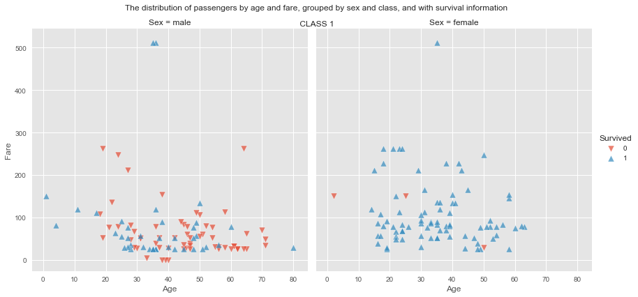

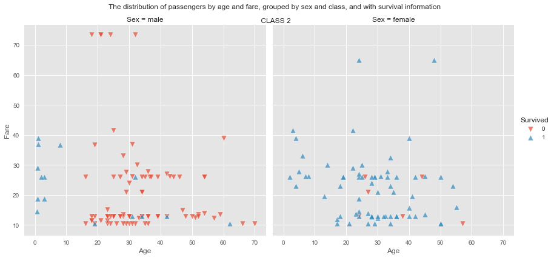

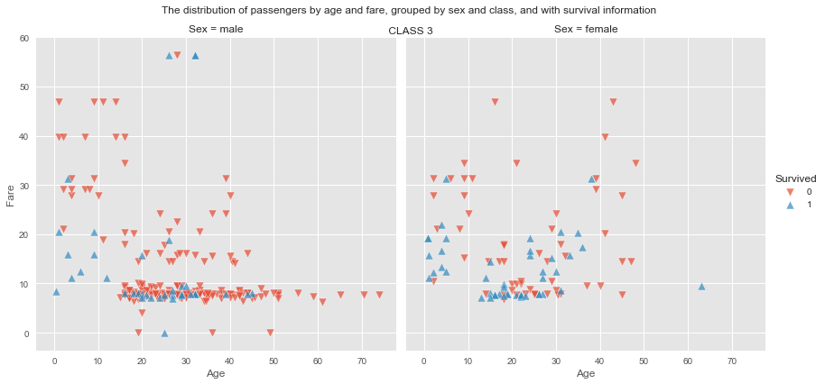

```python
def scatter_plot_class(pclass):
    g = sns.FacetGrid(data_clean_age[data_clean_age['Pclass'] == pclass],
                      col='Sex',
                      col_order=['male', 'female'],
                      hue='Survived',
                      hue_kws=dict(marker=['v', '^']),
                      size=6)

    g = (g.map(plt.scatter, 'Age', 'Fare', edgecolor='w', alpha=0.7, s=80).add_legend())
    #plt.subplots_adjust(top=0.9)
    #g.fig.suptitle('CLASS {}'.format(pclass))
    plt.subplots_adjust(top=0.9)
    g.fig.suptitle('The distribution of passengers by age and fare, grouped by sex and class, and with survival information\n\n CLASS {}'.format(pclass))
# plotted separately because the fare scale for the first class makes it difficult to visualize second and third class charts
#plt.title('the distribution of passengers by age and fare, grouped by sex and class, and with survival information')

scatter_plot_class(1)
scatter_plot_class(2)
scatter_plot_class(3)
```

Well all the graphs are perfect!!! In the above graphs we can easily differentiate that women have the higher survival rate specially for the first and second classes.

Let's find the survival rate by class, sex and age-range. We will also plot them for better understanding.

**Survivors according to class**

In the above analysis we can see that there were three classes; class 1= first, class 2= second, class 3= third. In the ancient years also upper class people were given more advantage over lower and middle class. This can be seen below from the graph and proportion of people survived.

```python
table=pd.crosstab(data_clean_age['Survived'],data_clean_age['Pclass'])
print (table)
```

```
Pclass      1   2    3
Survived
0          64  90  270
1         122  83   85
```

```python
survived_by_class=data_clean_age.groupby('Pclass').Survived.mean()
print (survived_by_class)
```

```
Pclass
1    0.655914
2    0.479769
3    0.239437
Name: Survived, dtype: float64
```

**Survivors according to sex**

Let's see how the sex affected the total number of survivors.Here we will see how females were preferred over males.

```python
table = pd.crosstab(data_clean_age['Survived'],data_clean_age['Sex'])
print (table)
```

```
Sex       female  male
Survived
0             64   360
1            197    93
```

In the above analysis it can be seen that number of females survived as compared to men is more. As we all have in the movie "Titanic" also that the women and children were asked to wear life jackets first. And according to the titanic dataset we can see that **197** females survived while only **93** males were saved.

```python
survived_by_sex=data_clean_age.groupby('Sex').Survived.mean()
print survived_by_sex
```

```
Sex
female    0.754789
male      0.205298
Name: Survived, dtype: float64
```

**Survivors according to age**

Here we are doing a little change. We are describing the age range.

```python
survived_by_age = data_clean_age.groupby('AgeRange')['Survived'].mean()
survived_by_age
```

```
AgeRange
adult    0.381933
child    0.590361
Name: Survived, dtype: float64
```

We will not plot the graphs:

```
(0.0, 1.0)
```

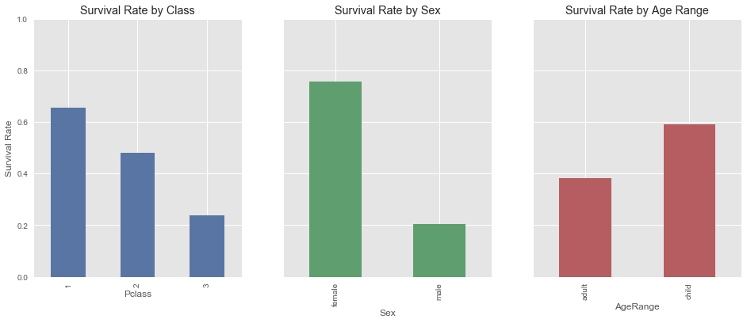

```python
fig, (axis1,axis2,axis3) = plt.subplots(1, 3, figsize=(16,6))

ax = survived_by_class.plot.bar(ax=axis1, color='#5975A4', title='Survival Rate by Class', sharey=True)
ax.set_ylabel('Survival Rate')
ax.set_ylim(0.0,1.0)
ax = survived_by_sex.plot.bar(ax=axis2, color='#5F9E6E', title='Survival Rate by Sex', sharey=True)
ax.set_ylim(0.0,1.0)
ax = survived_by_age.plot.bar(ax=axis3, color='#B55D60', title='Survival Rate by Age Range', sharey=True)
ax.set_ylim(0.0,1.0)
```

As expected the first class has a higher survival rate than the second, which has a higher survival rate than the third, and women and children have a higher chance of survival than men and adults, respectively.

Now combining all the factors and analysing the plot

```python
grouped_data = pd.concat(
    [data_clean_age.groupby(['Pclass', 'Sex', 'AgeRange'])['Survived'].mean(),
     data_clean_age.groupby(['Pclass', 'Sex', 'AgeRange'])['Survived'].count()],
    axis=1)
grouped_data.columns = ['Survived', 'Count']
grouped_data
```

| Pclass | Sex | AgeRange | Survived | Count |
| --- | --- | --- | --- | --- |
| 1 | female | adult | 0.975610 | 82 |
|  |  | child | 0.666667 | 3 |
|  | male | adult | 0.377551 | 98 |
|  |  | child | 1.000000 | 3 |
| 2 | female | adult | 0.906250 | 64 |
|  |  | child | 1.000000 | 10 |
|  | male | adult | 0.066667 | 90 |
|  |  | child | 1.000000 | 9 |
| 3 | female | adult | 0.430556 | 72 |
|  |  | child | 0.533333 | 30 |
|  | male | adult | 0.128889 | 225 |
|  |  | child | 0.321429 | 28 |

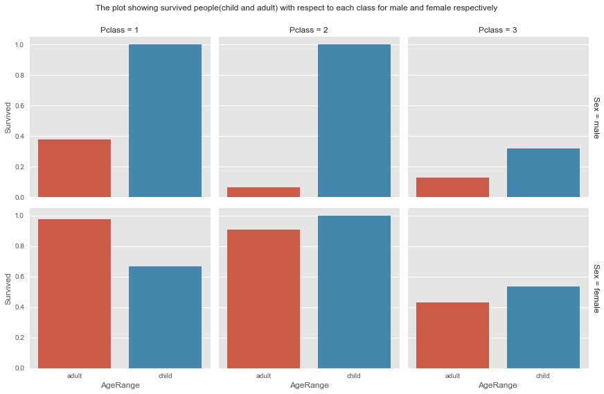

```python
g = sns.factorplot(
    x='AgeRange',
    y='Survived',
    col='Pclass',
    row='Sex',
    data=data_clean_age,
    margin_titles=True,
    kind="bar",
    ci=None)
plt.subplots_adjust(top=0.9)
g.fig.suptitle('The plot showing survived people(child and adult) with respect to each class for male and female respectively')
```

Analysing the three factors combined gives us expected results too. It is interesting to see that even the women from the third class have a higher survival rate than the men from first. It indicates that saving women had a higher priority than saving the richer classes.

Saving children also seemed like a higher priority as on all permutations of factors except first class women, where one of three female children died, they had a higher survival rate.

So we can conclude that saving women and children was indeed a priority on the Titanic shipwreck.

**Now we will look at the other question**

**Comparing fare for men and women**

While looking at the scatter plots shown in the first question I noticed that women seemed to be more spreaded among the ‘Fare’ axis, so I decided me to check if the average fare paid by women was really higher than men’s.

```python
fare_by_sex = data.groupby('Sex')['Fare'].mean()
fare_by_sex
```

```
Sex
female    44.479818
male      25.523893
Name: Fare, dtype: float64
```

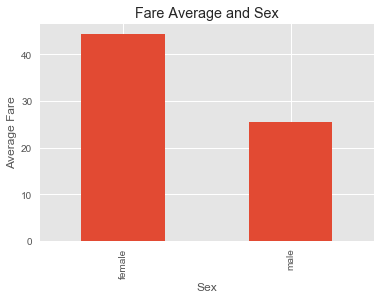

```python
ax = fare_by_sex.plot.bar(title='Fare Average and Sex')
ax.set_ylabel('Average Fare')
```

We can see that women paid way more than men on average. Women’s average fare is higher than I expected. Maybe it is due to the women of the first class. Let’s group the data by class and check it out:

```python
fare_by_class_sex = data.groupby(['Pclass', 'Sex'])['Fare'].mean()
fare_by_class_sex
```

```
Pclass  Sex
1       female    106.125798
        male       67.226127
2       female     21.970121
        male       19.741782
3       female     16.118810
        male       12.661633
Name: Fare, dtype: float64
```

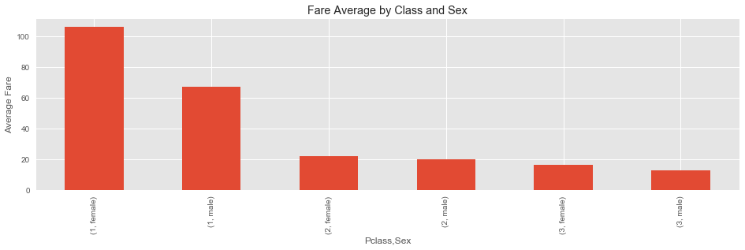

```python
ax = fare_by_class_sex.plot.bar(figsize=(16,4), title='Fare Average by Class and Sex')
ax.set_ylabel('Average Fare')
```

The average fare paid by women is higher than men’s on every class, although the fares on second class are almost equal.

**What fraction of the passengers embarked on each port? Is there a difference in their survival rates?** Let’s find out the proportion of passengers embarked on each port (C = Cherbourg; Q = Queenstown; S = Southampton), and their survival rates, but first, removing rows with missing embarkment values:

```python
# removing missing embarked values
data_clean_embarked = data.dropna(subset=['Embarked'])
embarked = data_clean_embarked.groupby('Embarked').mean()
embarked['Count'] = data_clean_embarked['Embarked'].value_counts()
embarked
```

| Embarked | PassengerId | Survived | Pclass | Age | SibSp | Parch | Fare | Count |
| --- | --- | --- | --- | --- | --- | --- | --- | --- |
| C | 445.357143 | 0.553571 | 1.886905 | 30.814769 | 0.386905 | 0.363095 | 59.954144 | 168 |
| Q | 417.896104 | 0.389610 | 2.909091 | 28.089286 | 0.428571 | 0.168831 | 13.276030 | 77 |
| S | 449.527950 | 0.336957 | 2.350932 | 29.445397 | 0.571429 | 0.413043 | 27.079812 | 644 |

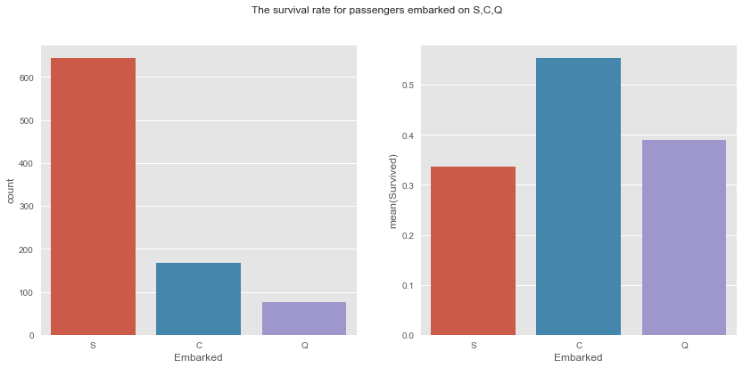

```python
fig, (axis1,axis2) = plt.subplots(1, 2, figsize=(14,6))

sns.countplot(x='Embarked', data=data_clean_embarked, order=['S','C','Q'], ax=axis1)
sns.barplot(x=embarked.index, y='Survived', data=embarked, order=['S','C','Q'], ax=axis2)
sns.plt.suptitle('The survival rate for passengers embarked on S,C,Q')
```

The survival rate for passengers embarked on Cherbourg is higher than both other ports. That is no wonder, since the mean ‘Pclass’ value for this port is 1.89 - way lower than Queenstown’s 2.91 and Southampton’s 2.35 - which means that people that embarked there belonged to richer classes, which we’ve already seen that have better survival rates than the poorer ones.

## 5. Conclusion

### 5.1 Limitations of Dataset

The are a number of limitations with the Titanic Dataset, which are caused by:

- missing data
- only been a sample of the data

The missing data and size of the sample could skew the results for example the missing ages.

```python
missing_ages = data[data['Age'].isnull()]
print missing_ages.groupby('Sex').size()
```

```
Sex
female     53
male      124
dtype: int64
```

The above shows that there were 53 ages missing for females and 124 ages missing for males. I had a choice with how to handle the missing ages each with their pros and cons.

- delete the rows with the missing ages - this would limit the accuracy of the analysis of the gender and class, however the accuracy of the analysis of the Age factor would be more accurate
- generate ages based on the mean of ages - this could skew the results of the age analysis.

### 5.2 About the Results

All the results presented on this report just show correlations between pieces of data. It is important to highlight that correlation does not imply causation. To make statistically valid statements, tests like chi-squared tests and t-tests should be applied.

To discover if class, sex and age have a relationship with survival, we make four chi-squared tests - one for each variable individually, and one for all combined - and find out if they really do matter, as this study suggests.

The same goes to find out if the embarkment site have relationships with survival.

To find out if the average fare was the same for men and women we must hypothesize that there was no difference, and then make a t-test to check if the difference is significative as this study suggests.

### 5.3 Other variables

As with most datasets the more information we have the better it can be analysed. I believe that we could add the following variables:

- passenger or crew - the current dataset doesn't distingush between passenger or crew, however from history we know that a mixture of both survived.
- life boat number - the reason why there were so many fatalities on board the Titanic was due to there not been enough lifeboats. I believe that if we knew the lifeboat number and the capacity of a lifeboat we could determine if it was possible for more people to survive